# Course Project

Claudio Vasconcelos Braga

1 de setembro de 2016

# 1)OBJECTIVE

Research on activity recognition has traditionally focus on discriminating between different activities, i.e. to predict “which” activity was performed at a specic point in time. The quality of executing an activity, the “how (well)”, has only received little attention so far, even though it potentially provides useful information for a large variety of applications.

In this work we build a model that predict the manner in which the dumbbell lifting is executed. We will also apply the model on a test base.

# 2)COLLECTED DATA

Six male participants were asked to perform one set of 10 repetitions of the Unilateral Dumbbell Biceps Curl in five different fashions: Class A - Exactly according to the specification Class B - Throwing the elbows to the front Class C - lifting the dumbbell only halfway Class D - lowering the dumbbell only halfway Class E - Throwing the hips to the front

The variables register the values of 4 sensors (glove, armband, lumbar belt and dumbbell). For feature extraction we used a sliding window approach with different lengths from 0.5 second to 2.5 seconds, with 0.5 second overlap. In each step of the sliding window approach we calculated features on the Euler angles (roll, pitch and yaw), as well as the raw accelerometer, gyroscope and magnetometer readings. For the Euler angles of each of the four sensors we calculated eight features: mean, variance, standard deviation, max, min, amplitude, kurtosis and skewness, generating in total 96 derived feature sets.

As training data, We use the following database:

https://d396qusza40orc.cloudfront.net/predmachlearn/pml-training.csv

The database has 19622 observation and 160 variables.

# 3)DATA PREPARATION

Before built the model, we did the steps bellow:

3.1)Excluding variables with more than 30% of NA.

Total:100 variables excluded.

3.2)Excluding variables not important

Excluded variables: X, raw_timestamp_part_1, raw_timestamp_part_2, cvtd_timestamp, new_window, num_window

3.3) Excluding variables with correlation >0.9

Hightly correlated (>0.9):

```
##      [,1]               [,2]
## [1,] "total_accel_belt" "roll_belt"
## [2,] "accel_belt_y"     "roll_belt"
## [3,] "accel_belt_y"     "total_accel_belt"
## [4,] "gyros_forearm_z"  "gyros_dumbbell_z"
```

Excluded Variables: roll_belt, total_accel_belt and gyros_dumbbell_z.

3.4) Removal of outliers

# 4) Data visualization

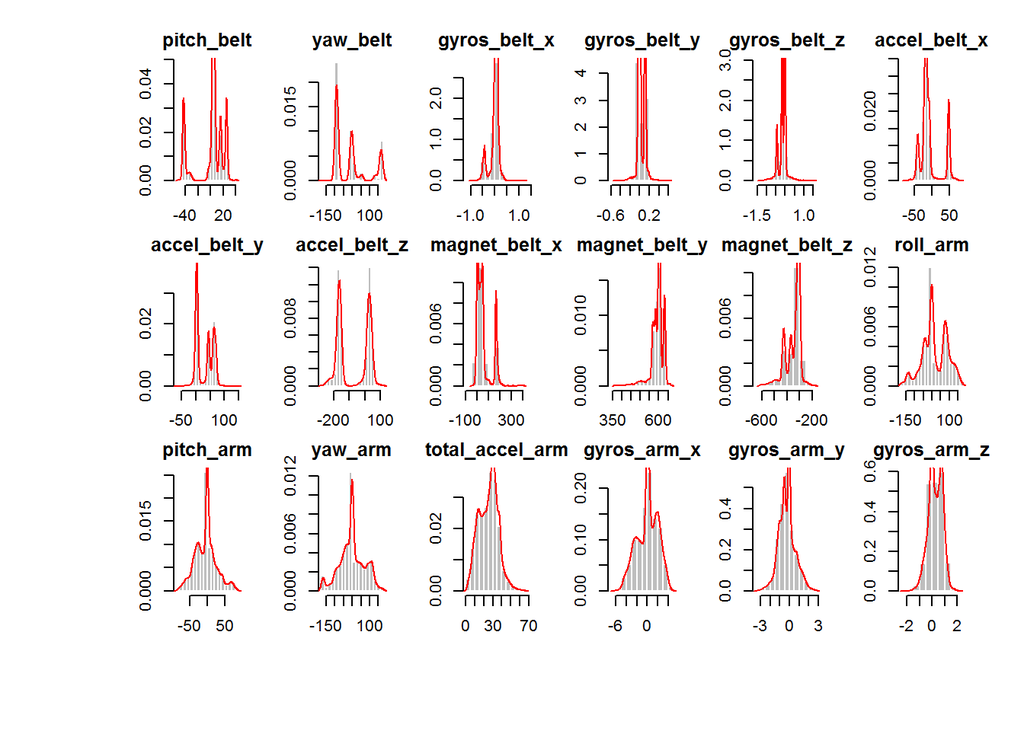

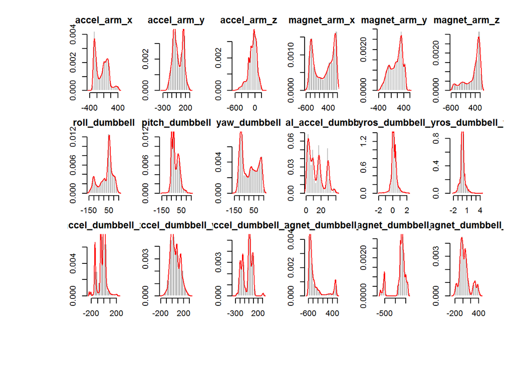

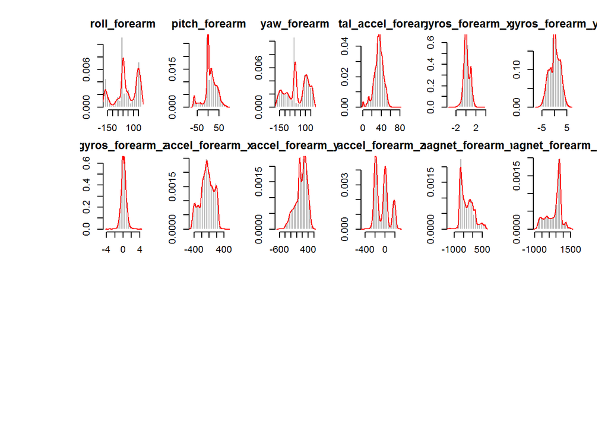

# 5) Data Partition

The data (19550 observations) were divided into:

Train 59.9948849%

Test 20.0153453%

Val 19.9897698%

# 6) Data Normalization

All numeric variables from Train, Test and Validation were normalized considering the Train dataset.

# 7) Modelling

We used Random Forest with bootstrapping as crosvalidation.

We used the test set to measure the accuracy of the model.

Confusion Matrix:

```
##           Reference
## Prediction    A    B    C    D    E
##          A 1015   19   77    0    4
##          B  319  231  193   17    0
##          C  340   24  321    0    0
##          D  295   14  225  110    0
##          E  146  125  197   30  211
```

# 8) Quiz4

We used the model to predict 20 different test cases.

The result is:

```
##  [1] B A B A A E D B A A B C B A E E A B B B
## Levels: A B C D E
```